# Analysis of fairness based on talent and value in the hiring and remuneration processes

A special focus on gender parity

Report prepared for Black Saber Software by SFP

2021-04-21

# Executive summary

**Background & Aim** :

Concerns about potential bias in the hiring and remuneration processes were consistently raised internally in Black Saber Software. In order to investigate the true fact for the issues, we SFP were consent to help figure it out. This report was commissioned to examine if potential issues especially gender parity existed in the hiring, promotion and salary processes based on the hiring data and data about promotion and wages for current employees provided by Black Saber Software . Besides, we were interested in the fact how the new trialled AI service performanced in the hiring process.

**Limitations** :

We were only offered with data for current employees so it was hard to know reasons past employees left. If additional data related to past employees can be provided, we can have a more deep and comprehensive sight into potential biases; The lack of ethnicity/race data also results in a limitation since race might be a potential exist which might influence the results of hiring pipelines and promotion and amount of wages; No information about the determination methods for hiring results, promotion and amount of salary was provided which limited the accuracy of models we fit for these processes.

# Technical report

## Introduction

Recently, several complaints were received related to potential bias in the hiring and remuneration processes. Hence, BSS (Black Saber Software) required our team to take a look and give out a related report for the Board of Directors. The purpose of this study is to investigate if BSS’s hiring, promotion, and salary were processing fairly based on talent and value to the company. We were especially interested in exploring potential gender bias in the hiring and remuneration processes. Besides, we also investigated the performance of the new AI service in the hiring pipeline. Data was provided by the data team from BSS including hiring data for their new graduate program and data for their current employees.

In this report, we will specify different explanatory and response variables for. Then, we will fit several generalized linear models and a linear mixed effects model to analyze the results. At the end, we will point out the same limitations of our model. The whole report will be run on R.studio and knit into pdf.

## Research questions

- Does the new AI service in the hiring pipeline work and is reliable for future use?
- In particular, is gender a potential bias during the promotion and salary processes?
- If the promotion, and salary process are all fair to all employees and based on their ability and value to BSS?

## Models and Results

### Hiring Process for applicants

**Relationships between whether a candidate was hired or not and the variables during the entire hiring process**

applicant_id = Unique identifier assigned to candidates in Phase 1  
team_applied_for = Data or Software  
gpa = 0.0 to 4.0  
extracurriculars = Indicates the quality of extracurricular involvement with scores of 0,1,2  
work_experience = Description of candidates’ previous work experience with scores of 0,1,2  
technical_skills = Score from 0 to 100 on a timed technical task, AI autograded  
writing_skills = Score from 0 to 100 on a timed writing task, AI autograded  
speaking_skills = A rating of speaking skills based on pre-recorded video, AI autograded  
leadership_presence = A rating of leadership presence based on pre-recorded video, AI autograded  
final_result = Indicate at which phase applicant was rejected or hired finally  
result = Show the hiring result for each applicant in each hiring pipeline

| **Characteristic** | **log(OR)**<sup>1</sup> | **95% CI**<sup>1</sup> | **p-value** |
| --- | --- | --- | --- |
| gpa | -2.4 | -4.5, -0.77 | 0.009 |
| cv | -16 |  | >0.9 |
| cover_letter | -16 |  | >0.9 |
| extracurriculars | -1.6 | -3.6, -0.22 | 0.042 |
| work_experience | 0.40 | -1.0, 2.0 | 0.6 |

<sup>*1*</sup> OR = Odds Ratio, CI = Confidence Interval

model_1

**Is the AI used during the hiring process reliable.**

| **Characteristic** | **log(OR)**<sup>1</sup> | **95% CI**<sup>1</sup> | **p-value** |
| --- | --- | --- | --- |
| gpa | 0.67 | -0.74, 2.2 | 0.4 |
| extracurriculars | 0.33 | -1.0, 1.7 | 0.6 |
| work_experience | 0.01 | -1.4, 1.5 | >0.9 |
| leadership_presence | -1.0 | -1.5, -0.62 | <0.001 |
| speaking_skills | -0.74 | -1.1, -0.43 | <0.001 |
| technical_skills | -0.09 | -0.14, -0.05 | <0.001 |
| writing_skills | -0.10 | -0.15, -0.05 | <0.001 |

<sup>*1*</sup> OR = Odds Ratio, CI = Confidence Interval

model_2

### Promotion and Salary Processes for current employees

In the current employee data set, we have selected gender, team, leadership_for_level, productivity, and salary. Based on the label dictionary, obtained along with the data, each variables represent the following:

employee_id = Unique 5-digit employee identifier  
gender = Gender of employee: man, woman, prefer not to say  
team = one of the 8 teams which each employee works for  
leadership_for_level = if the employee is appropriate for level, need improvements or exceeds expectations  
productivity = work output with respect to job description rated on a 0 - 100 scale  
salary = salary at the given financial quarter

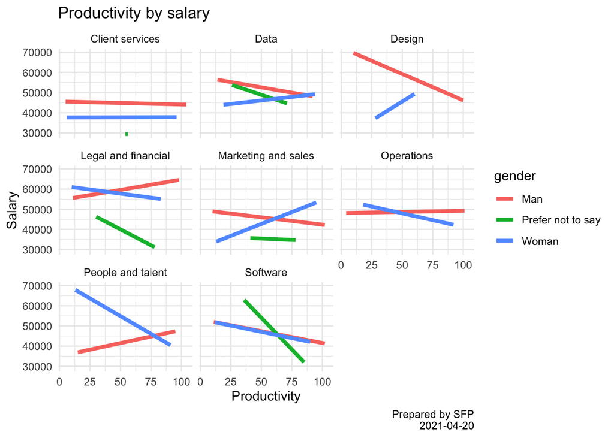

```
## Linear mixed model fit by REML ['lmerMod']
## Formula: salary ~ gender + team + (1 | employee_id)
##    Data: black_saber_current_employees
##
## REML criterion at convergence: 146211.6
##
## Scaled residuals:
##     Min      1Q  Median      3Q     Max
## -7.3488 -0.2548 -0.0127  0.2108  7.7525
##
## Random effects:
##  Groups      Name        Variance  Std.Dev.
##  employee_id (Intercept) 270852785 16458
##  Residual                 68844147  8297
## Number of obs: 6906, groups:  employee_id, 607
##
## Fixed effects:
##                         Estimate Std. Error t value
## (Intercept)                39400       1696  23.234
## genderPrefer not to say    -4115       5405  -0.761
## genderWoman                -4723       1447  -3.263
## teamData                    7246       2418   2.997
## teamDesign                 12415       4348   2.855
## teamLegal and financial    10743       3346   3.211
## teamMarketing and sales     3280       2198   1.492
## teamOperations              5932       2397   2.475
## teamPeople and talent       7471       3548   2.106
## teamSoftware                4227       2136   1.979
##
## Correlation of Fixed Effects:
##             (Intr) gnPnts gndrWm teamDt tmDsgn tmLgaf tmMras tmOprt tmPpat
## gndrPrfrnts -0.075
## genderWoman -0.485  0.105
## teamData    -0.549 -0.010  0.027
## teamDesign  -0.352  0.021  0.110  0.212
## tmLglandfnn -0.407 -0.086  0.045  0.274  0.155
## tmMrktngans -0.636 -0.037  0.099  0.417  0.240  0.308
## teamOpertns -0.576  0.025  0.072  0.381  0.219  0.276  0.423
## tmPplandtln -0.353  0.009 -0.025  0.255  0.140  0.183  0.279  0.257
## teamSoftwar -0.724 -0.011  0.243  0.433  0.263  0.322  0.494  0.446  0.283
```

|  | #Df | LogLik | Df | Chisq | Pr(>Chisq) |
| --- | --- | --- | --- | --- | --- |
| 1 | 12 | -73105.79 | NA | NA | NA |
| 2 | 24 | -58577.91 | 12 | 29055.75 | 0 |

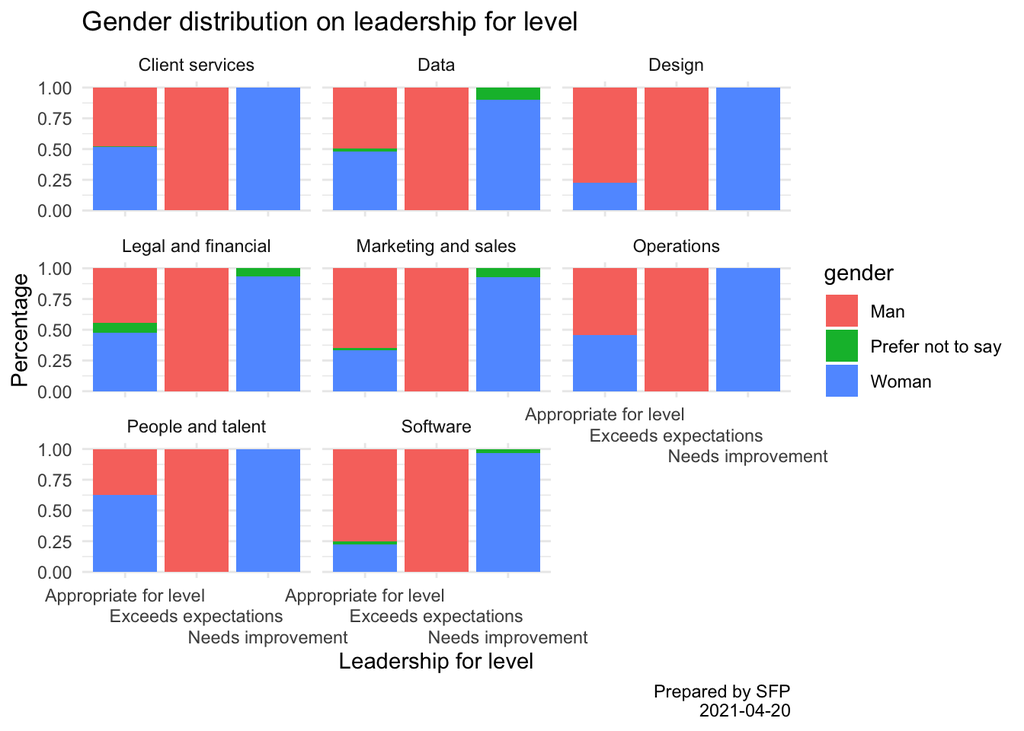

## Discussion

First, we explored the effects the various variables during the hiring phases had on the hiring chances. Fitting a model to model the applicant’s hiring result (no if not hired, yes if hired) against the applicant’s GPA,Curriculum Vitae, cover letter, extracurriculars, and work_experience, it was found that only the GPA and extracurriculars had a significant effect on the being hired, with p-values of 0.009 and 0.042 respectively.

## Strengths and limitations

One limitation is that we were only provided data on current employees. The data of previous past employees is missing. Regarding the promotion and salary processes, past employees’ information could give us some insights to why they left the company. This could give valuable information such as whether they were treated evenly. If we can get the past employees’ data, we can analyze whether there exist biases during the remuneration process more comprehensively.

Another limitation results from the lack of ethnicity/race data for both the hiring and remuneration processes which could also be a potential bias that we need to check. We were told that the race data was not collected by the People and Talent team but they were considering it for EDI initiatives. The race might also be a factor that would affect the hiring result of applicants and also the promotion and wages processes of employees.

Finally, a limitation may be introduced as a result of implicit evaluation criterions for each hiring phase, especially AI-autograded phase and remuneration process. If we know how applicants can proceed to the next round in the hiring process, it would be easier to identify what effects are correlated and fit better models. For the remuneration process, if we can know what kinds of employees can be promoted or have higher salary, we will be able to explore more about potential biases.

# Consultant information

## Consultant profiles

**Dandan Zhang**. Dandan is a junior consultant with SFP. She earned her Bachelor of Science, majoring in Mathematics and Statistics, from the University of Toronto in 2021.She specializes in data visualization.

**Jong-Hoon Kim** John is a senior consultant with SFP. He earned his Bachelor of Science in statistics and economics, from the University of Toronto in 2021. He specialises in data analysis and visualisation.

**Zikun Lei** Zikun Lei is a senior consultant with SFP. He earned his Bachelor of Science in statistics and economics, from the University of Toronto in 2021. He specialises in data analysis and visualisation.

## Code of ethical conduct

SFP is a statistical consulting company. Our mission is to help our clients solve their problems and give them professional and practical advice. We, all staff in SFP adhere to the Code of Ethics Conduct as outlined below.

**Professional Integrity and Accountability:** We always serve our clients with integrity and respect. No fabricated or altered data that deliberately affects the results will be used. We promise to be fully qualified with accepted work and be honest to clients if any limitation of competence exists. Appropriate and relevant statistical methods are always used to produce reliable results. All results and conclusions should be clearly explained in detail with statistical data and valid analytic approaches.

**Responsibilities to clients:** We treat all clients’ information confidential and responsible. No client’s information should be disclosed or discussed in public without permissions of the clients. We will protect any sensitive data or results from unauthorized people and will not take advantage of them to make profit.

**Responsibilities to other statisticians:** We always safeguard the reputation of statistical practice and try to enhance our professionalism. We support and help strengthen the work of other fellow statisticians through valuable peer view. No criticism is allowed to cast on individuals rather than on problems. Even in debates, we should be respectful of others.